# Лабораторная работа №2

Компьютерный практикум по статистическому анализу

Надежда Александровна Рогожина

1132222840@rudn.ru

Российский университет дружбы народов

2025-09-27

# Информация

## Докладчик

- Рогожина Надежда Александровна
- студентка 4 курса НФИбд-02-22
- Российский университет дружбы народов им. П. Лумумбы
- 1132222840@rudn.ru
- https://MikoGreen.github.io/ru/

# Введение

## Цель работы

Основная цель работы — изучить несколько структур данных, реализованных в Julia, научиться применять их и операции над ними для решения задач.

## Задание

1. Используя Jupyter Lab, повторите примеры из раздела 2.2.
2. Выполните задания для самостоятельной работы (раздел 2.4).

## Теоретическое введение

Научные вычисления традиционно требуют высочайшей производительности, однако эксперты по доменам в значительной степени перенесены на более медленные динамические языки для ежедневной работы. К счастью, методы современного языка и компилятора позволяют в основном устранить компромисс производительности и обеспечивать достаточно продуктивную среду для прототипирования и достаточно эффективно для развертывания применений, интенсивных производительности. Язык программирования Julia заполняет эту роль: это гибкий динамический язык, подходящий для научных и численных вычислений, с производительностью, сравнимой с традиционными статичными языками.

# Выполнение лабораторной работы

## Задание №1

Первым заданием было повторить примеры, где были показаны основы работы с кортежами, словарями, множествами и массивами.

## Примеры

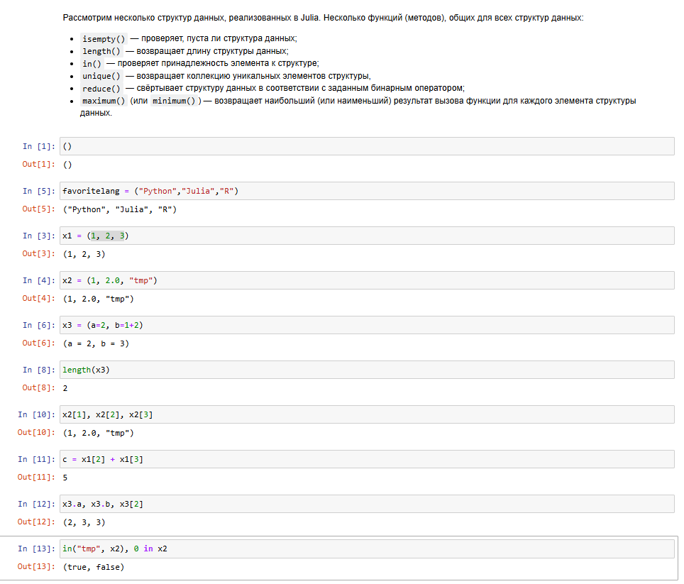

Рисунок 1: Кортежи

## Примеры

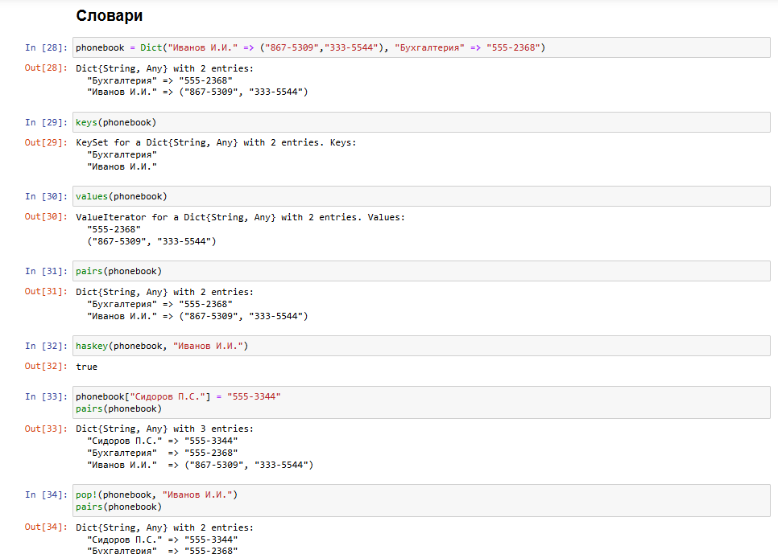

Рисунок 2: Словари

## Примеры

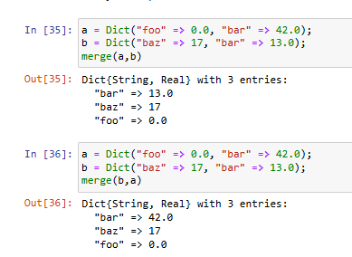

Рисунок 3: Словари

## Примеры

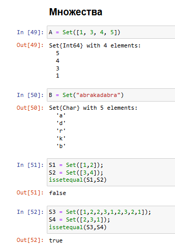

Рисунок 4: Множества

## Примеры

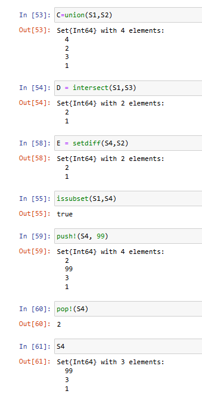

Рисунок 5: Множества

## Примеры

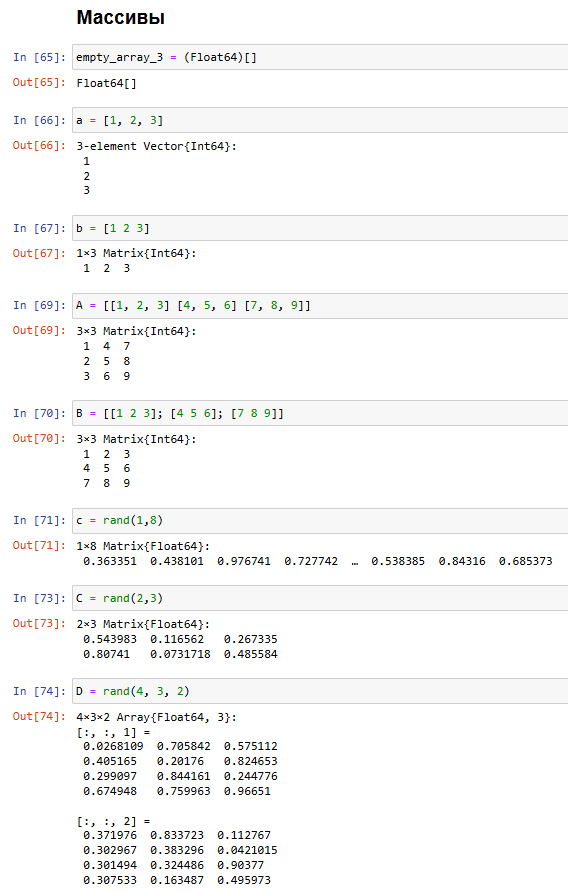

Рисунок 6: Массивы

## Примеры

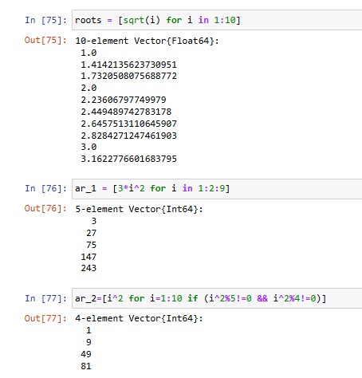

Рисунок 7: Массивы

## Примеры

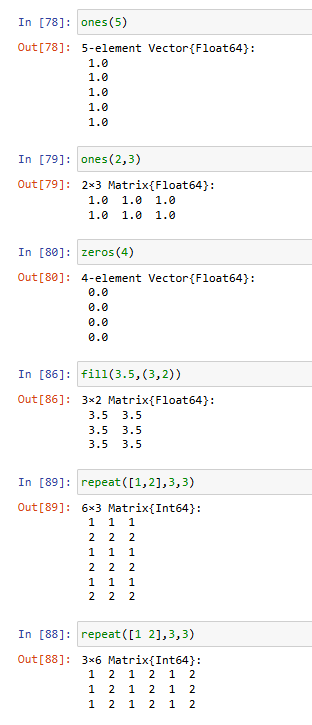

Рисунок 8: Массивы

## Примеры

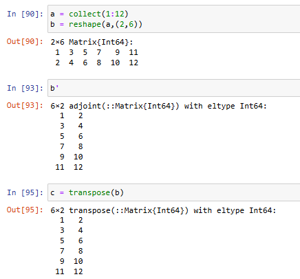

Рисунок 9: Массивы

## Примеры

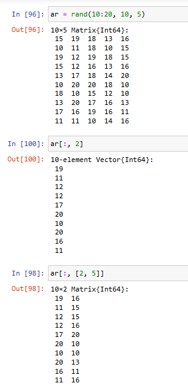

Рисунок 10: Массивы

## Примеры

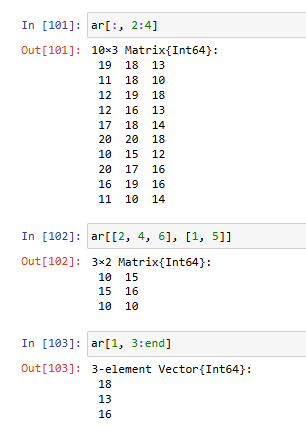

Рисунок 11: Массивы

## Примеры

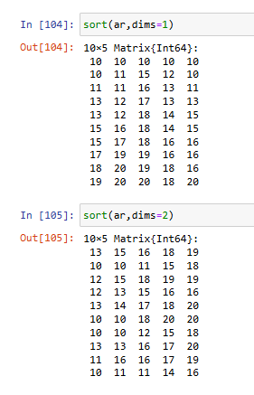

Рисунок 12: Массивы

## Примеры

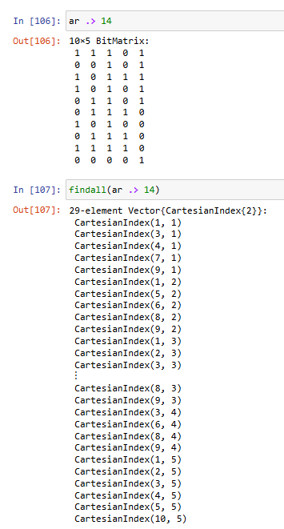

Рисунок 13: Массивы

## Задание №2

Далее, необходимо было выполнить *Задания для самостоятельного выполнения*

## Задачи для самостоятельного выполнения

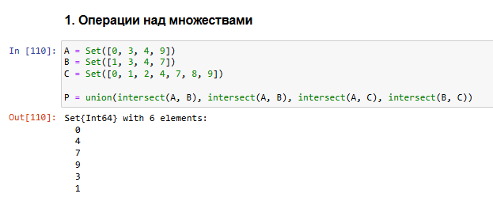

Рисунок 14: Объединение множеств

## Задачи для самостоятельного выполнения

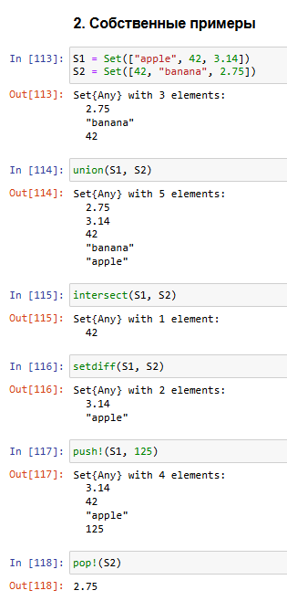

Рисунок 15: Собственные примеры

## Задачи для самостоятельного выполнения

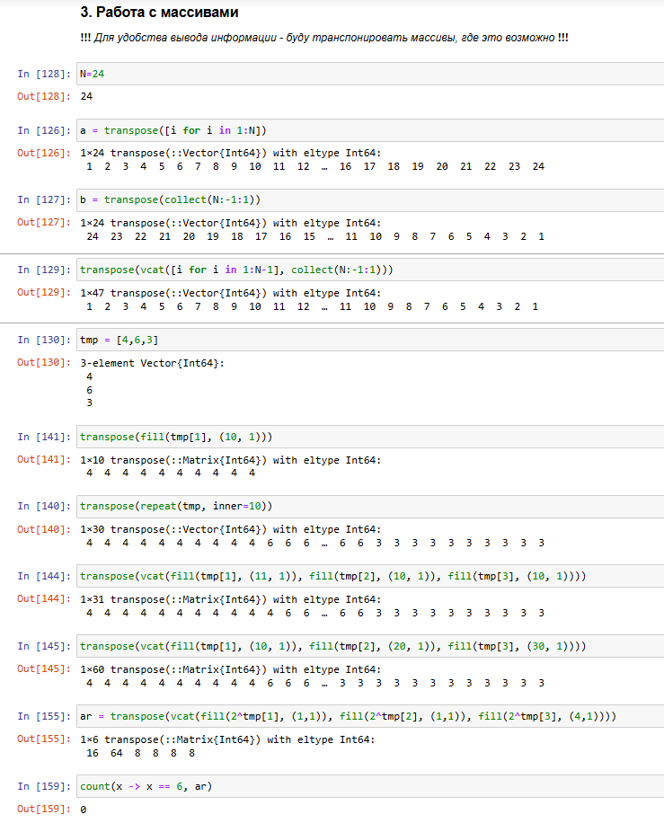

Рисунок 16: Работа с массивами

## Задачи для самостоятельного выполнения

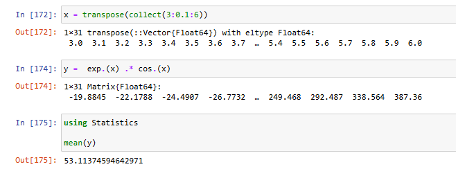

Рисунок 17: Работа с массивами

## Задачи для самостоятельного выполнения

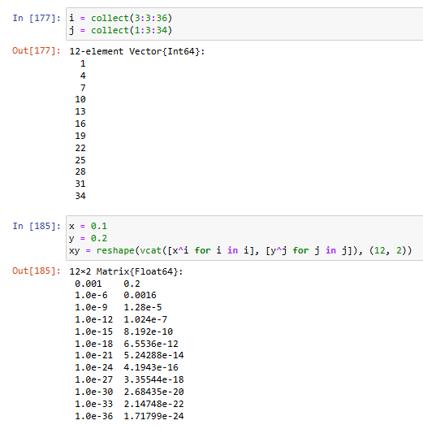

Рисунок 18: Работа с массивами

## Задачи для самостоятельного выполнения

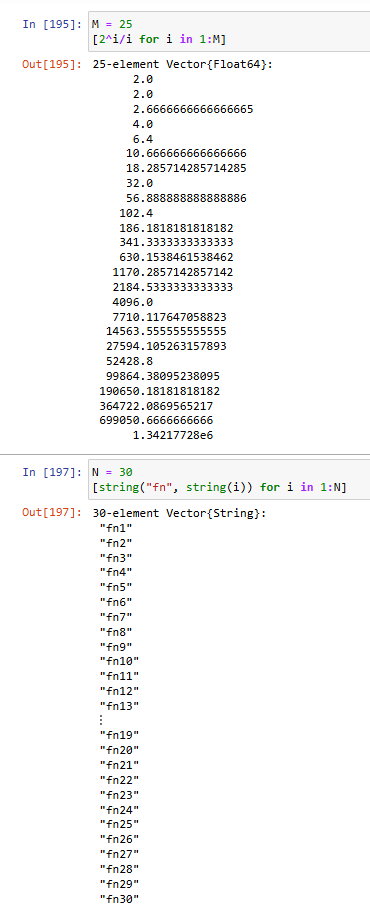

Рисунок 19: Работа с массивами

## Задачи для самостоятельного выполнения

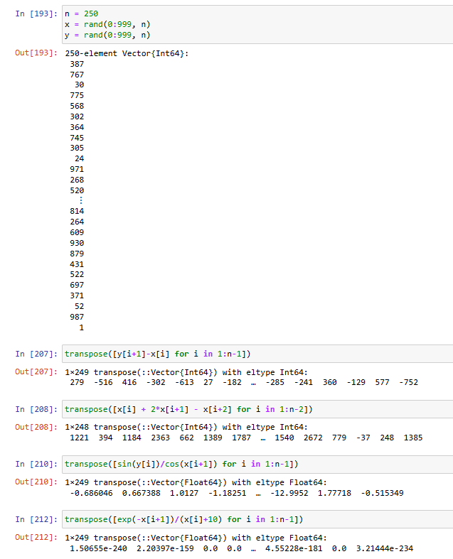

Рисунок 20: Работа с массивами

## Задачи для самостоятельного выполнения

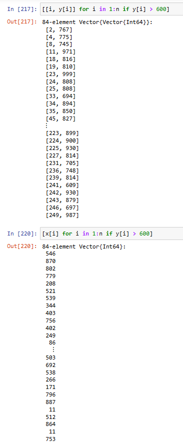

Рисунок 21: Работа с массивами

## Задачи для самостоятельного выполнения

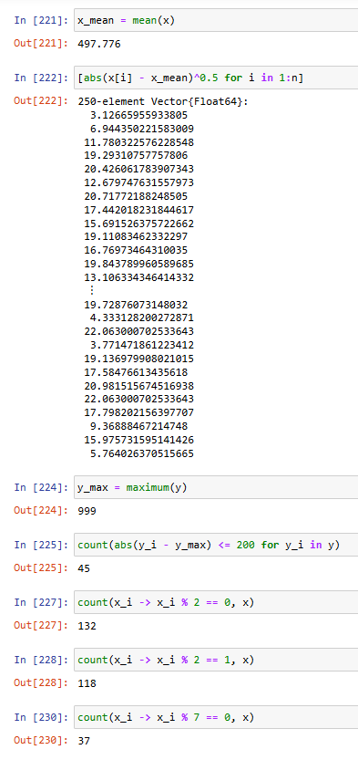

Рисунок 22: Работа с массивами

## Задачи для самостоятельного выполнения

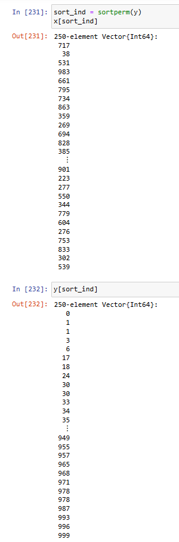

Рисунок 23: Работа с массивами

## Задачи для самостоятельного выполнения

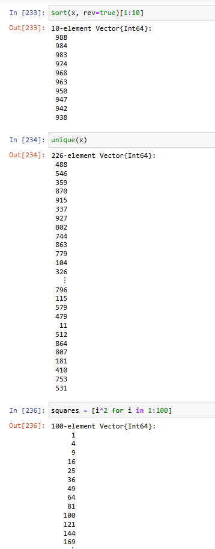

Рисунок 24: Работа с массивами

## Задачи для самостоятельного выполнения

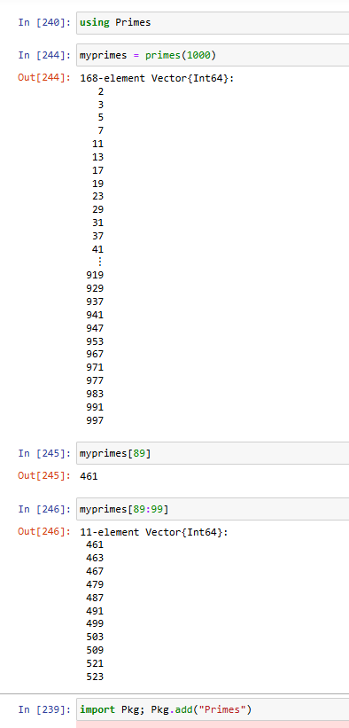

Рисунок 25: Работа с массивами

## Задачи для самостоятельного выполнения

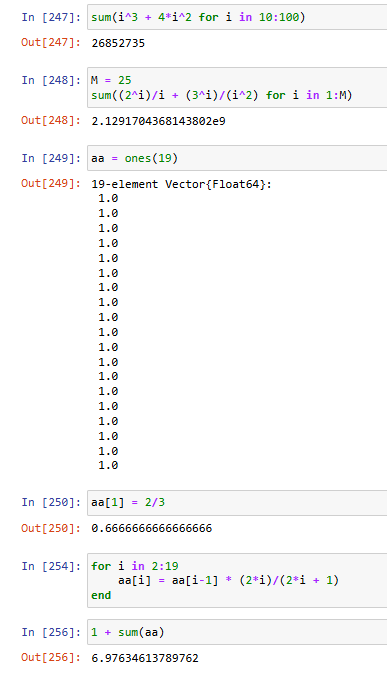

Рисунок 26: Работа с массивами

# Выводы

## Выводы

В ходе работы были изучены основы работы с разными типами структур в я.п. Julia.